# Explore Difference in Injury (and per Capita)

Benedito Chou

2019-04-19

## Setup Library

Install these packages if neccessary.

```r
library(readr)
library(gamlss)
library(tidyr)
library(knitr)
library(DT)
library(dplyr)
library(stringr)
library(scales)
library(broom)
library(ggplot2)
library(ggbeeswarm)
library(MASS)
library(pscl)
library(boot)
library(nlme)
library(cplm)
```

## Data Preparation

### Load Data

Load the data imported, processed and saved from “data wrangle change score centroid and map data.R”.

```r
load("processed_data v4.RData")
```

### Prepare Data

Keep distinct records within each time point only because keeping all pairwise records will inflate the number of observations in time 1 and 2.

```r
data_long <- distinct(merged_data_record_all_long, tribe, time, FIPS, .keep_all = TRUE)
```

Create data.frame to include only tribes with time 1 and 2 data.

```r
data_t1and2_long <- filter(data_long, tribe %in% tribes_time1and2_lst$tribe)
```

Convert time and tribe to factor for statistical modeling

```r
data_long <- data_long %>%
  ungroup() %>%
  mutate(tribe = factor(tribe),
         time = factor(time))

data_t1and2_long <- data_t1and2_long %>%
  ungroup() %>%
  mutate(tribe = factor(tribe),
         time = factor(time))
```

**Check Data**

First, confirm the data is correct, each tribe should have 2 summarized records in total, one for time 1 and one for time 2, so the resulted data.frame should has 0 row.

```r
t1and2_lst <- group_by(data_t1and2_long, tribe, time) %>%
  count() %>%
  ungroup() %>%
  group_by(tribe) %>%
  count() %>%
  filter(n < 2)

nrow(t1and2_lst)
```

```
## [1] 0
```

## Exploratory Analyses

### All Tribes, including those with time 1 or time 2 data only

### Plot Injury by Time

- The distribution of injury in time 1 and time 2 is skewed to the right and is zero-inflated with notable outliers.
- The distirbution of injury is in general higher in time 2 compared to time 1.

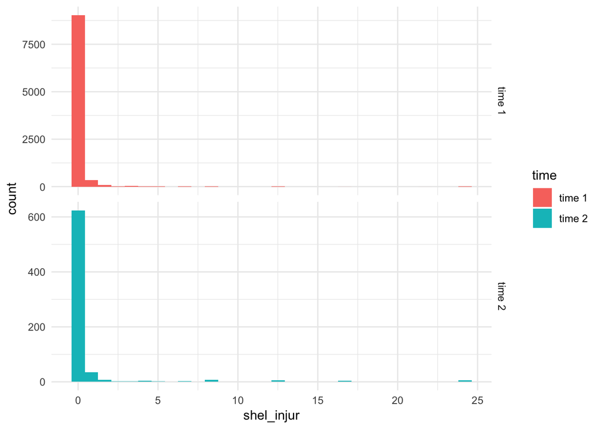

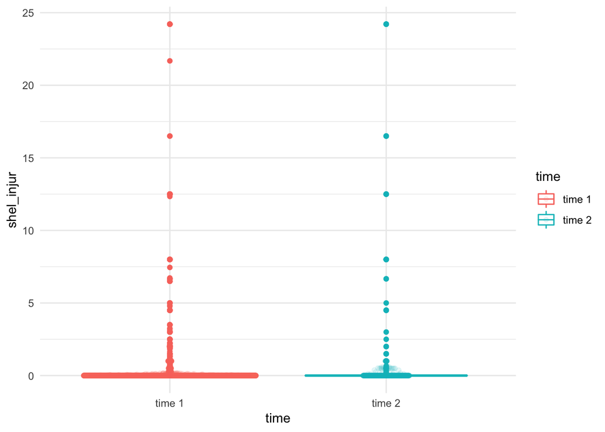

#### Look at those with injury only and 90th percentile cutoff

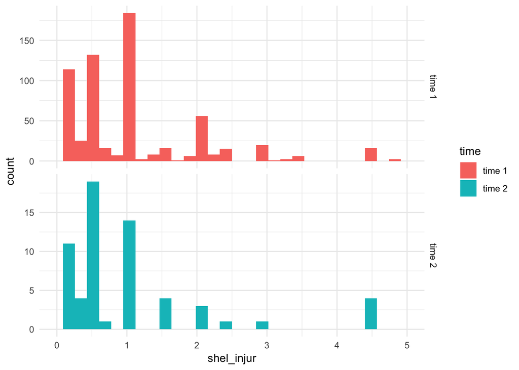

```r
data_long_shel_injur_only <- filter(data_long, shel_injur > 0)

ggplot(data_long_shel_injur_only, aes(shel_injur, fill = time)) +
  facet_grid(rows = vars(time), scales = "free") +
  geom_histogram(position = "dodge") +
  theme_minimal() +
  xlim(0, quantile(data_long_shel_injur_only$shel_injur, c(.90), na.rm = TRUE))
```

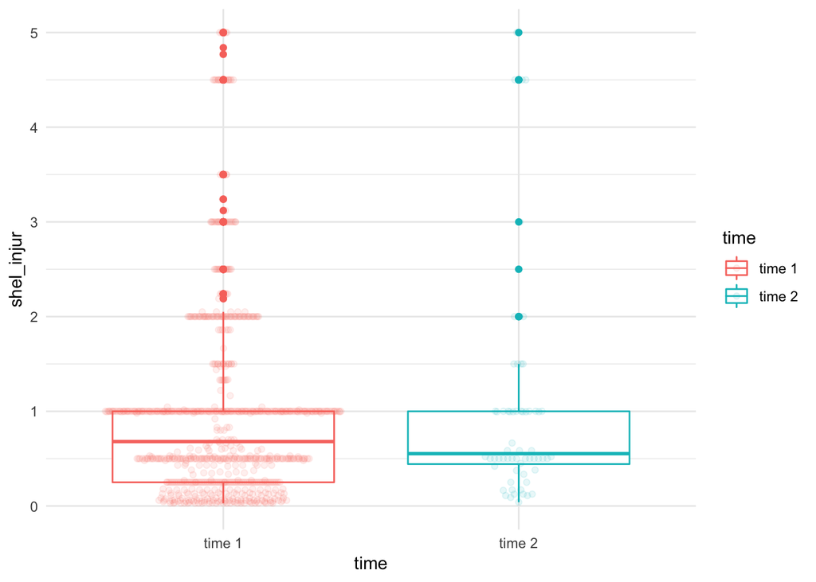

```r
ggplot(data_long_shel_injur_only, aes(time, shel_injur, colour = time)) +
  geom_boxplot() +
  geom_quasirandom(alpha = 1/10, varwidth = TRUE) +
  theme_minimal() +
  ylim(0, quantile(data_long_shel_injur_only$shel_injur, c(.90), na.rm = TRUE))
```

### Plot Injury per capita by Time

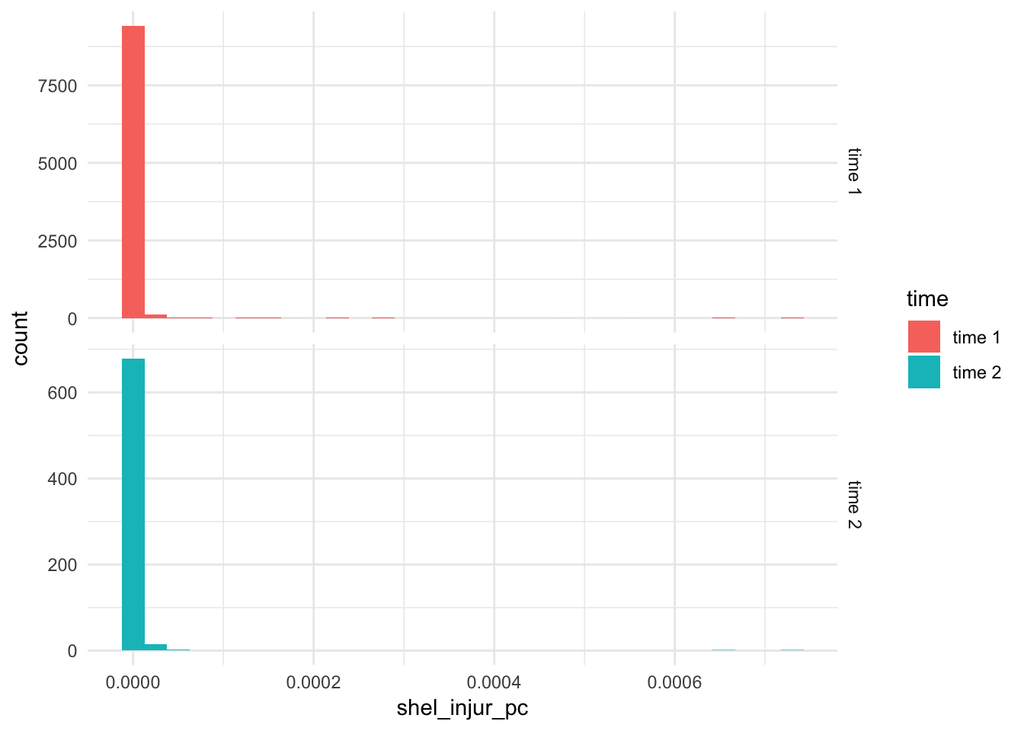

```r
ggplot(data_long, aes(shel_injur_pc, fill = time)) +
  facet_grid(rows = vars(time), scales = "free") +
  geom_histogram(position = "dodge", bin = 70) +
  theme_minimal()
```

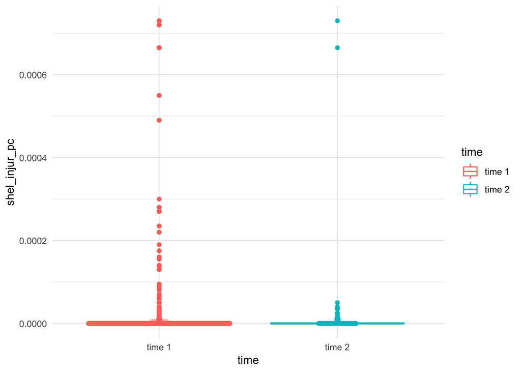

```r
ggplot(data_long, aes(time, shel_injur_pc, colour = time)) +
  geom_boxplot() +
  geom_quasirandom(alpha = 1/10, varwidth = TRUE) +
  theme_minimal()
```

#### Look at those with injury only and 90th percentile cutoff

- The distirbution of injury per capita is in general higher in time 2 compared to time 1 for tribes in counties with injury only.

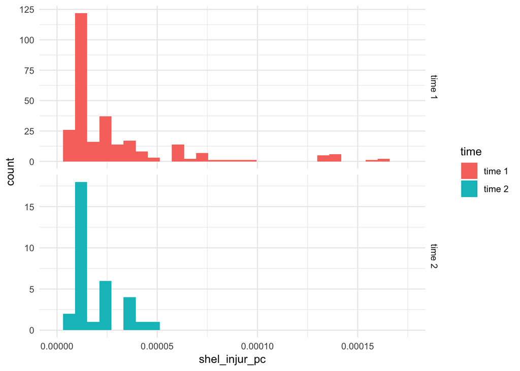

```r
data_long_shel_injur_pc_only <- filter(data_long, shel_injur_pc > 0)

ggplot(data_long_shel_injur_pc_only, aes(shel_injur_pc, fill = time)) +
  facet_grid(rows = vars(time), scales = "free") +
  geom_histogram(position = "dodge") +
  theme_minimal() +
  xlim(0, quantile(data_long_shel_injur_pc_only$shel_injur_pc, c(.90), na.rm = TRUE))
```

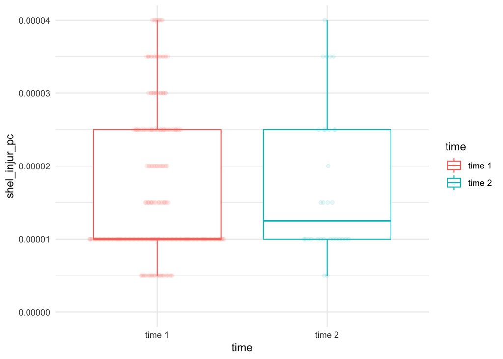

```r
ggplot(data_long_shel_injur_pc_only, aes(time, shel_injur_pc, colour = time)) +
  geom_boxplot() +
  geom_quasirandom(alpha = 1/10, varwidth = TRUE) +
  theme_minimal() +
  ylim(0, quantile(data_long_shel_injur_only$shel_injur_pc, c(.90), na.rm = TRUE))
```

### Tribes with both time 1 or time 2 data

### Plot Injury by Time

- The distribution of injury in time 1 and time 2 is skewed to the right and is zero-inflated with notable outliers.
- The distirbution of injury is in general higher in time 2 compared to time 1.

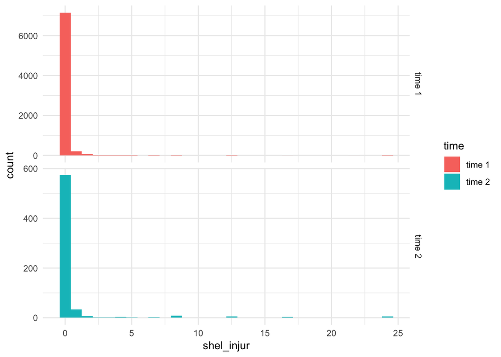

```r
ggplot(data_t1and2_long, aes(shel_injur, fill = time)) +
  facet_grid(rows = vars(time), scales = "free") +
  geom_histogram(position = "dodge", bin = 70) +
  theme_minimal()
```

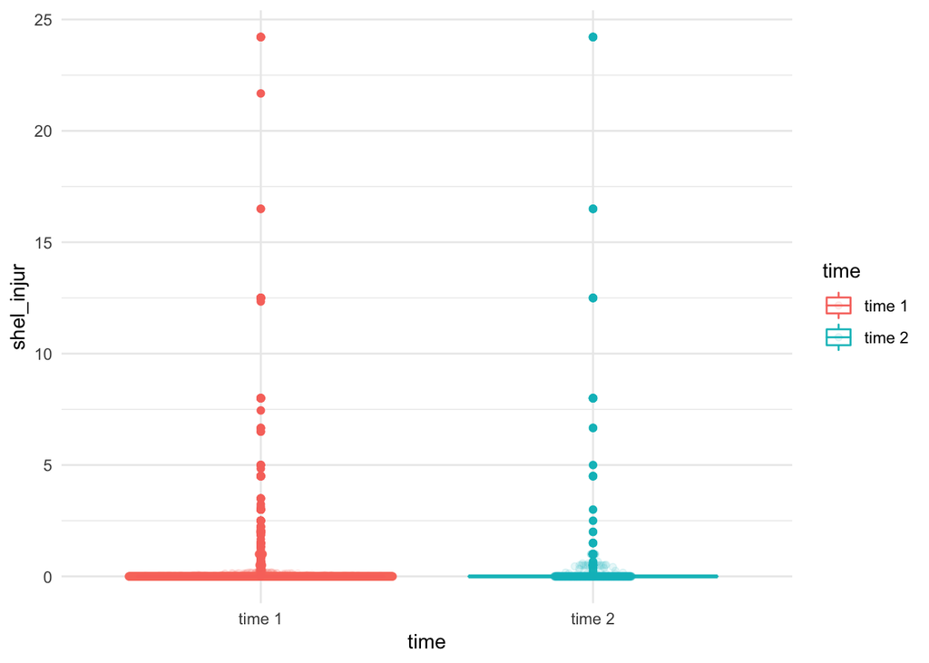

```r
ggplot(data_t1and2_long, aes(time, shel_injur, colour = time)) +
  geom_boxplot() +
  geom_quasirandom(alpha = 1/10, varwidth = TRUE) +
  theme_minimal()
```

#### Look at only those with injury only and 90th percentile cutoff

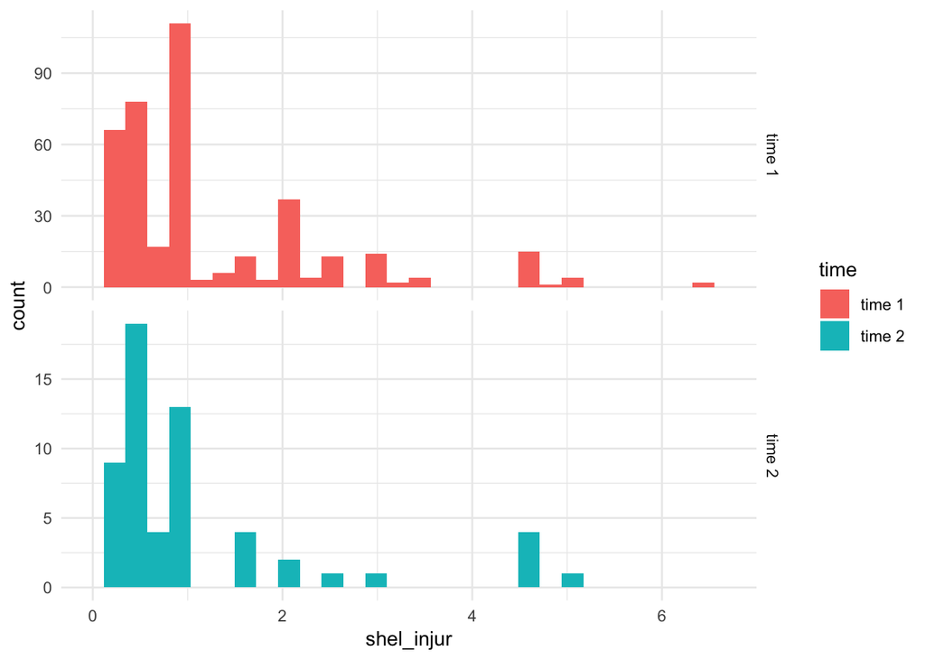

```r
data_t1and2_long_shel_injur_only <- filter(data_t1and2_long, shel_injur > 0)

ggplot(data_t1and2_long_shel_injur_only, aes(shel_injur, fill = time)) +
  facet_grid(rows = vars(time), scales = "free") +
  geom_histogram(position = "dodge") +
  theme_minimal() +
  xlim(0, quantile(data_t1and2_long_shel_injur_only$shel_injur, c(.90), na.rm = TRUE))
```

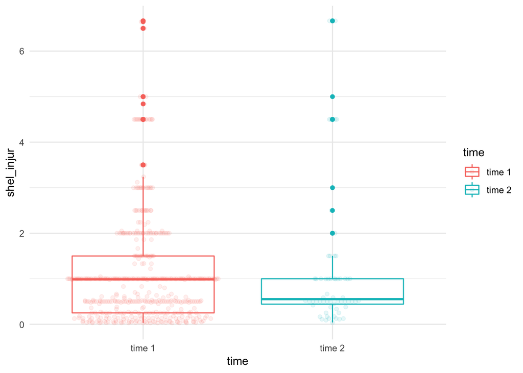

```r
ggplot(data_t1and2_long_shel_injur_only, aes(time, shel_injur, colour = time)) +
  geom_boxplot() +
  geom_quasirandom(alpha = 1/10, varwidth = TRUE) +
  theme_minimal() +
  ylim(0, quantile(data_t1and2_long_shel_injur_only$shel_injur, c(.90), na.rm = TRUE))
```

### Plot Injury per capita by Time

- The distribution of injury per capita in time 1 and time 2 is skewed to the right and is zero-inflated with notable outliers.
- The distirbution of injury per capita is in general higher in time 2 compared to time 1.

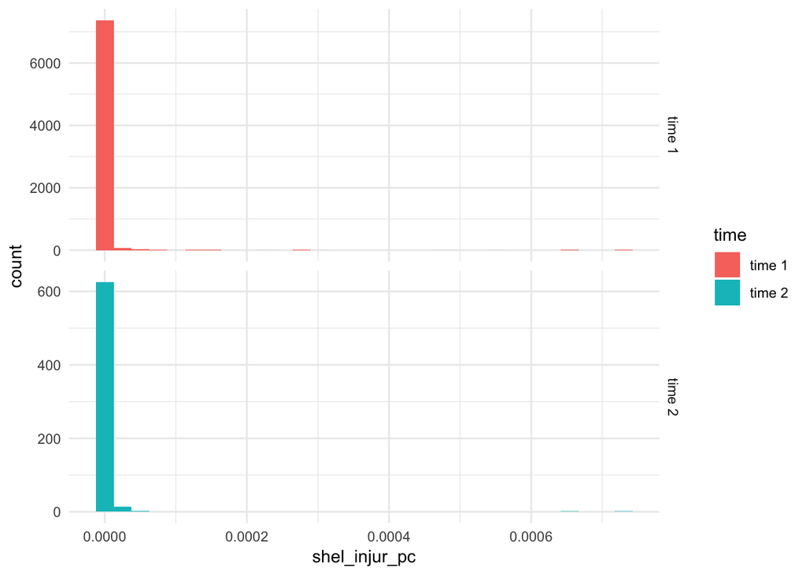

```r
ggplot(data_t1and2_long, aes(shel_injur_pc, fill = time)) +
  facet_grid(rows = vars(time), scales = "free") +
  geom_histogram(position = "dodge", bin = 70) +
  theme_minimal()
```

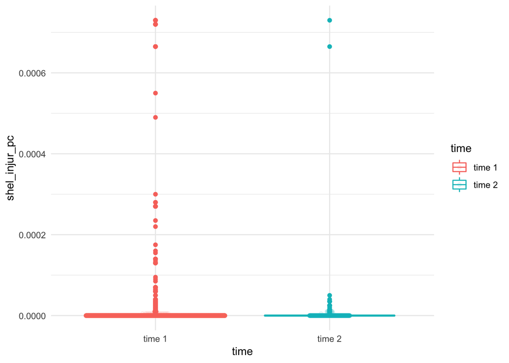

```r
ggplot(data_t1and2_long, aes(time, shel_injur_pc, colour = time)) +
  geom_boxplot() +
  geom_quasirandom(alpha = 1/10, varwidth = TRUE) +
  theme_minimal()
```

#### Look at those with injury only and 90th percentile cutoff

- The distirbution of injury per capita is in general higher in time 1 compared to time 2 for tribes in counties with injury only.

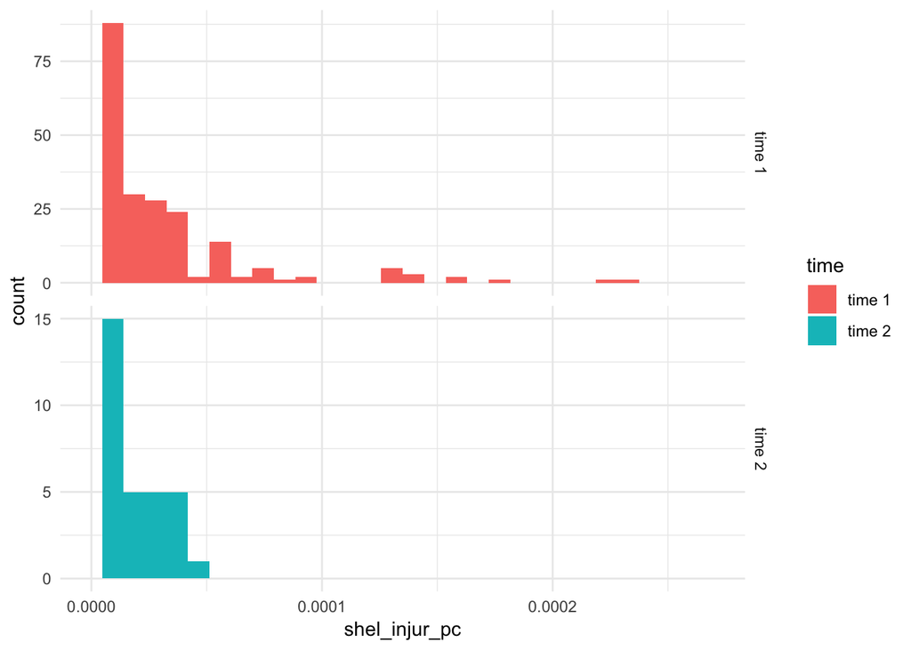

```r
data_t1and2_long_shel_injur_pc_only <- filter(data_t1and2_long, shel_injur_pc > 0)

ggplot(data_t1and2_long_shel_injur_pc_only, aes(shel_injur_pc, fill = time)) +
  facet_grid(rows = vars(time), scales = "free") +
  geom_histogram(position = "dodge") +
  theme_minimal() +
  xlim(0, quantile(data_t1and2_long_shel_injur_pc_only$shel_injur_pc, c(.90), na.rm = TRUE))
```

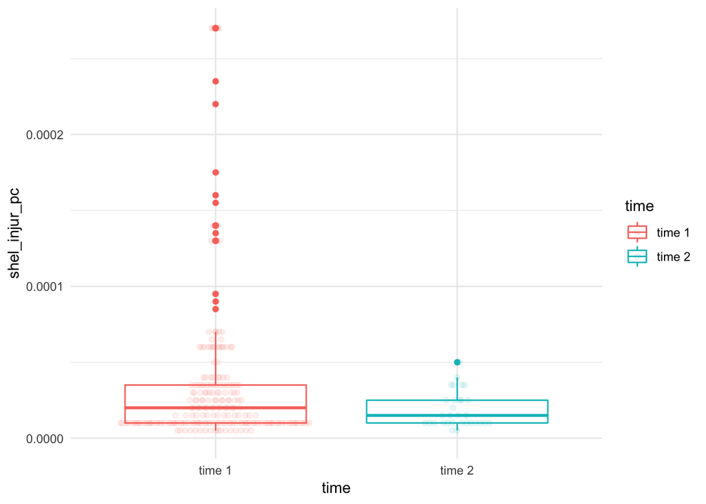

```r
ggplot(data_t1and2_long_shel_injur_pc_only, aes(time, shel_injur_pc, colour = time)) +
  geom_boxplot() +
  geom_quasirandom(alpha = 1/10, varwidth = TRUE) +
  theme_minimal() +
  ylim(0, quantile(data_t1and2_long_shel_injur_pc_only$shel_injur_pc, c(.90), na.rm = TRUE))
```

### Plot relationship between Time 1 and Time 2 Injury at tribe level

- Compute the mean and median values of each tribe at time 1 and time 2. Look at the median as well as the mean because the median is a robust measure of central tendency and extreme-value resistent while the mean is heavily influenced by outliers.

#### Relationship between Time 1 and Time 2 Injury

- We found a large positive linear relationships between time 1 and time 2 injury for mean (r = 0.8833) and for median (r = 0.6867)

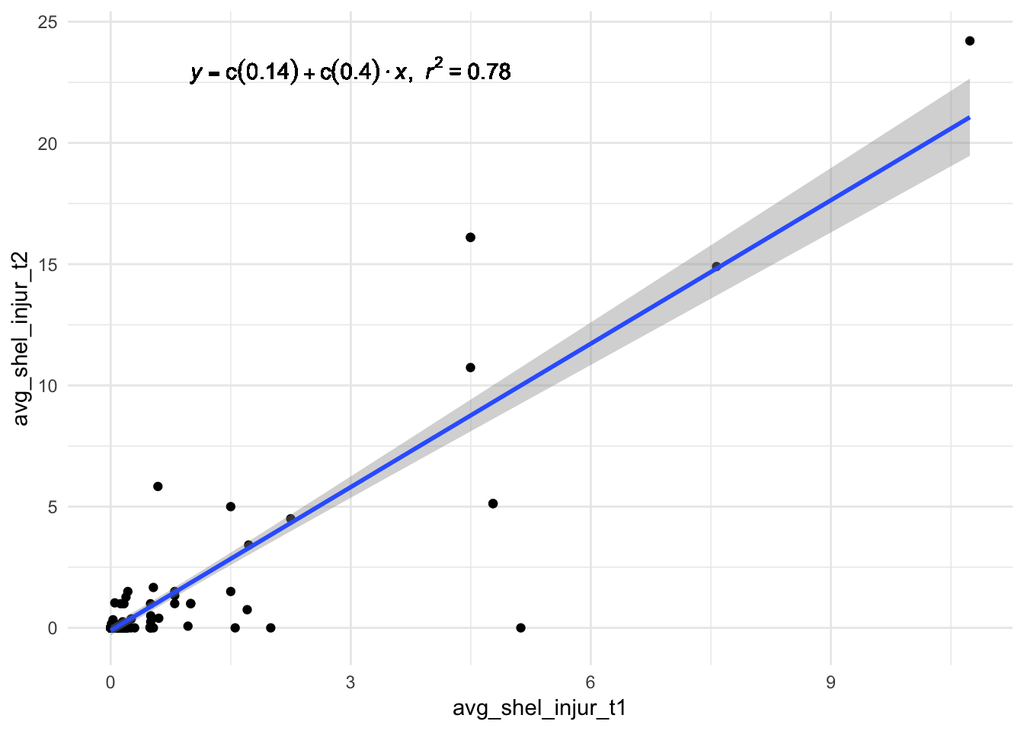

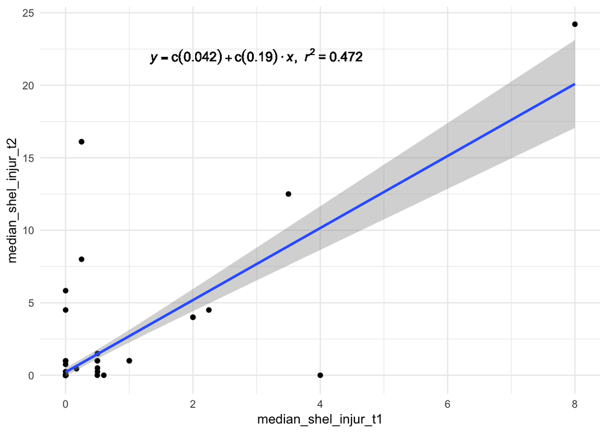

#### Relationship between Time 1 and Time 2 Injury per Capita

- We found a medium positive linear relationship between time 1 and time 2 injury per capita for mean (r = 0.2916) and a large positive linear relationship for median (r = 0.8802)
- To visually display the scatterplot with such small numbers, the per capita values are linearly transformed to be injury per capita per 100,000 people

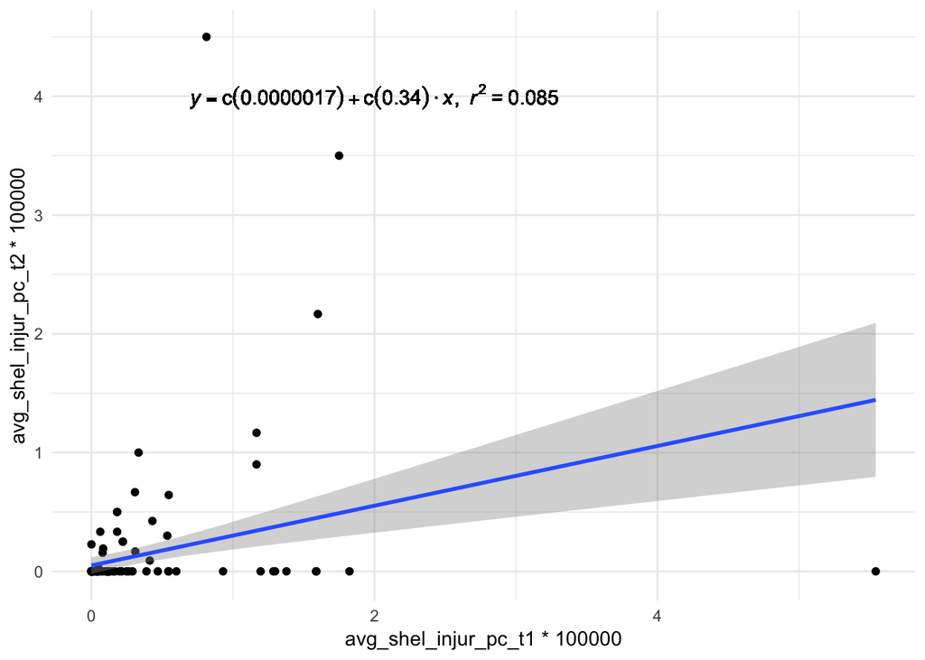

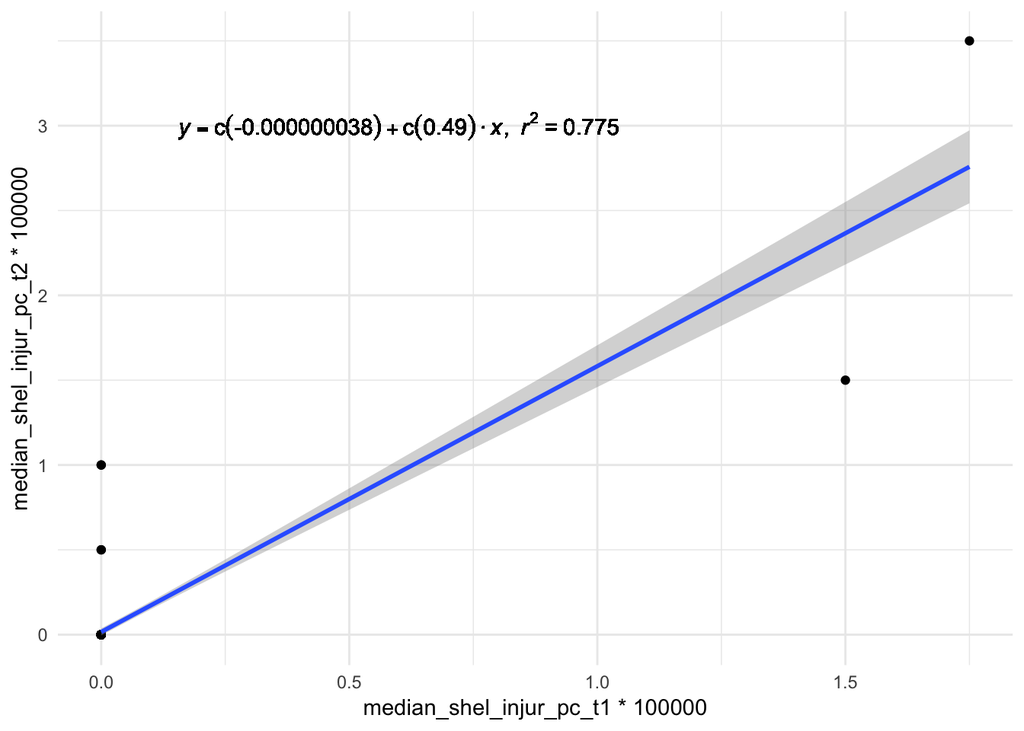

## Test for Significant Difference

### (1) Test for significant difference at the aggregate level

- We applied three statistical models - Linear Mixed Model, Repeated Measure ANOVA, and Zero-inflated Compound Poisson Generalized Linear Model - to examine statistical significant difference between Time 1 and Time 2 injury and injury per capita scores.
- The models, as applicable, are run using all records from all tribes and tribes with both time 1 and 2 data.
- The model interpretation is based on the Zero-inflated Compound Poisson Generalized Linear Model, as this is the test most appropraite for the outcome. The Linear Mixed Model and Repeated Measure ANOVA results are shown for reference purposes.

### Use all records

Filter out NA outcomes

```r
model_data_long <- filter(data_long, !is.na(shel_injur))
model_data_t1and2_long <- filter(data_t1and2_long, !is.na(shel_injur))
```

### Linear Mixed Model

- Linear mixed model is a parametric test for comparing data when one or more of the independent variables should be model as a random effect because of variations by that variable.

```r
# Linear Mixed Model raw
lme_model <- nlme::lme(shel_injur ~ time, data = model_data_long, random = ~1|tribe)

summary(lme_model)
```

```
## Linear mixed-effects model fit by REML
##  Data: model_data_long
##        AIC      BIC    logLik
##   32252.68 32281.64 -16122.34
##
## Random effects:
##  Formula: ~1 | tribe
##         (Intercept) Residual
## StdDev:    1.280875 1.099028
##
## Fixed effects: shel_injur ~ time
##                 Value  Std.Error   DF  t-value p-value
## (Intercept) 0.3794838 0.06922946 9909 5.481536       0
## timetime 2  0.2570349 0.04745660 9909 5.416209       0
##  Correlation:
##            (Intr)
## timetime 2 -0.104
##
## Standardized Within-Group Residuals:
##           Min            Q1           Med            Q3           Max
## -10.843387302  -0.087178579  -0.028766297  -0.007431011  19.313702723
##
## Number of Observations: 10308
## Number of Groups: 398
```

```r
anova(lme_model)
```

```
##             numDF denDF  F-value p-value
## (Intercept)     1  9909 36.93776  <.0001
## time            1  9909 29.33532  <.0001
```

```r
# Linear Mixed Model per capita
lme_model <- nlme::lme(shel_injur_pc ~ time, data = model_data_long, random = ~1|tribe)

summary(lme_model)
```

```
## Linear mixed-effects model fit by REML
##  Data: model_data_long
##       AIC     BIC   logLik
##   -183374 -183345 91690.99
##
## Random effects:
##  Formula: ~1 | tribe
##            (Intercept)      Residual
## StdDev: 0.000002876127 0.00003298873
##
## Fixed effects: shel_injur_pc ~ time
##                       Value       Std.Error   DF  t-value p-value
## (Intercept) 0.0000021341780 0.0000004360038 9909 4.894861  0.0000
## timetime 2  0.0000005431133 0.0000013113687 9909 0.414158  0.6788
##  Correlation:
##            (Intr)
## timetime 2 -0.241
##
## Standardized Within-Group Residuals:
##         Min          Q1         Med          Q3         Max
## -0.34136032 -0.06537154 -0.04878738 -0.03526479 21.92870872
##
## Number of Observations: 10308
## Number of Groups: 398
```

```r
anova(lme_model)
```

```
##             numDF denDF   F-value p-value
## (Intercept)     1  9909 26.492198  <.0001
## time            1  9909  0.171526  0.6788
```

### Repeated Measure ANOVA

- See Analysis below: Repeated Measure ANOVA can only be run with tribes with both time 1 and time 2 data.

### Zero-Inflated Compound Poisson Generalized Linear Model

- Zero-inflated Compound Poisson Generalized Linear Model is a parametric test for comparing continous metrics with excessive zeros. Unlike t-test or ANOVA, this test is appropriate for data that has a non-normally distribute positive scores with a large amount of zero score, such as the outcome injury and injury per capita. It is a two-part models. The first part evalutes whether the outcome is zero or non-zero, the second part models the positive distribution of the non-zero scores. Different predictors can be entered to predict the outcomes in these two-parts.
- Time is entered as a predictor in both the zero-inflated and positive scores part of the modeling.

```r
# Zero-Inflated Compound Poisson Generalized Linear Model! raw
zcpglm_model <- zcpglm(shel_injur ~ time || time, link = "log", data = model_data_long, optimizer = "nlminb")

zcpglm_model_summary <- summary(zcpglm_model)
```

```
##
## Call:
## zcpglm(formula = shel_injur ~ time || time, link = "log", data = model_data_long,
##     optimizer = "nlminb")
##
## Zero-inflation model coefficients:
##             Estimate Std. Error z value Pr(>|z|)
## (Intercept)   -15.49    1499.31  -0.010    0.992
## timetime 2     12.78    1499.31   0.009    0.993
##
## Compound Poisson model coefficients:
##             Estimate Std. Error z value             Pr(>|z|)
## (Intercept) -1.89121    0.05651 -33.470 < 0.0000000000000002 ***
## timetime 2   1.41741    0.21325   6.647        0.00000000003 ***
## ---
## Signif. codes:  0 '***' 0.001 '**' 0.01 '*' 0.05 '.' 0.1 ' ' 1
##
## Estimated dispersion parameter: 14.825
## Estimated index parameter: 1.6154
```

```r
model_para <- coef(zcpglm_model_summary)

mean_t1 <- round(mean(filter(data_long, time == "time 1")$shel_injur, na.rm = T), 3)
mean_t2 <- round(mean(filter(data_long, time == "time 2")$shel_injur, na.rm = T), 3)
sd_t1 <- round(sd(filter(data_long, time == "time 1")$shel_injur, na.rm = T), 3)
sd_t2 <- round(sd(filter(data_long, time == "time 2")$shel_injur, na.rm = T), 3)

pvalue <- round(model_para$tweedie[2,4], 3)
zvalue <- round(model_para$tweedie[2,3], 3)
parameter <- NA
```

**Interpretation**

- At the aggregate level, the difference in injury between time 1 (M = 0.151, SD = 1.106) and time 2 (M = 0.584, SD = 2.805) was statistically signficant (z = 6.647, p < .001).

```r
# Zero-Inflated Compound Poisson Generalized Linear Model! per capita
zcpglm_model <- zcpglm(shel_injur_pc ~ time || time, link = "log", data = model_data_long, optimizer = "L-BFGS-B") # "nlminb" does not converge

zcpglm_model_summary <- summary(zcpglm_model)
```

```
##
## Call:
## zcpglm(formula = shel_injur_pc ~ time || time, link = "log",
##     data = model_data_long, optimizer = "L-BFGS-B")
##
## Zero-inflation model coefficients:
##             Estimate Std. Error z value Pr(>|z|)
## (Intercept) -4.41192         NA      NA       NA
## timetime 2   0.03274         NA      NA       NA
##
## Compound Poisson model coefficients:
##              Estimate Std. Error  z value            Pr(>|z|)
## (Intercept) -12.84979    0.08137 -157.916 <0.0000000000000002 ***
## timetime 2    0.10258    0.34306    0.299               0.765
## ---
## Signif. codes:  0 '***' 0.001 '**' 0.01 '*' 0.05 '.' 0.1 ' ' 1
##
## Estimated dispersion parameter: 0.75902
## Estimated index parameter: 1.6389
```

```r
# bezi_model <- tidy(bezi_model)
model_para <- coef(zcpglm_model_summary)

mean_t1 <- round(mean(filter(data_long, time == "time 1")$shel_injur, na.rm = T), 3)
mean_t2 <- round(mean(filter(data_long, time == "time 2")$shel_injur, na.rm = T), 3)
sd_t1 <- round(sd(filter(data_long, time == "time 1")$shel_injur, na.rm = T), 3)
sd_t2 <- round(sd(filter(data_long, time == "time 2")$shel_injur, na.rm = T), 3)

pvalue <- round(model_para$tweedie[2,4], 3)
zvalue <- round(model_para$tweedie[2,3], 3)
parameter <- NA
```

**Interpretation**

- At the aggregate level, the difference in injury per capita between time 1 (M = 0.151, SD = 1.106) and time 2 (M = 0.584, SD = 2.805) was not statistically signficant (z = 0.299, p = 0.765).

### Use only records where tribes have time 1 and 2 data

### Linear Mixed Model

```r
# Linear Mixed Model raw
lme_model <- nlme::lme(shel_injur ~ time, data = model_data_t1and2_long, random = ~1|tribe)

summary(lme_model)
```

```
## Linear mixed-effects model fit by REML
##  Data: model_data_t1and2_long
##       AIC      BIC   logLik
##   25020.4 25048.43 -12506.2
##
## Random effects:
##  Formula: ~1 | tribe
##         (Intercept) Residual
## StdDev:    1.510012 1.075975
##
## Fixed effects: shel_injur ~ time
##                 Value Std.Error   DF  t-value p-value
## (Intercept) 0.4171499 0.1149854 7974 3.627850  0.0003
## timetime 2  0.2548364 0.0470629 7974 5.414805  0.0000
##  Correlation:
##            (Intr)
## timetime 2 -0.084
##
## Standardized Within-Group Residuals:
##           Min            Q1           Med            Q3           Max
## -11.623598114  -0.086080333  -0.029085517   0.001230273  19.727367709
##
## Number of Observations: 8159
## Number of Groups: 184
```

```r
anova(lme_model)
```

```
##             numDF denDF  F-value p-value
## (Intercept)     1  7974 16.80373  <.0001
## time            1  7974 29.32012  <.0001
```

```r
# Linear Mixed Model per capita
lme_model <- nlme::lme(shel_injur_pc ~ time, data = model_data_t1and2_long, random = ~1|tribe)

summary(lme_model)
```

```
## Linear mixed-effects model fit by REML
##  Data: model_data_t1and2_long
##         AIC       BIC   logLik
##   -143843.3 -143815.3 71925.65
##
## Random effects:
##  Formula: ~1 | tribe
##            (Intercept)      Residual
## StdDev: 0.000003107353 0.00003570637
##
## Fixed effects: shel_injur_pc ~ time
##                       Value       Std.Error   DF  t-value p-value
## (Intercept) 0.0000024393249 0.0000005568885 7974 4.380275  0.0000
## timetime 2  0.0000005014289 0.0000014868556 7974 0.337241  0.7359
##  Correlation:
##            (Intr)
## timetime 2 -0.263
##
## Standardized Within-Group Residuals:
##         Min          Q1         Med          Q3         Max
## -0.31685701 -0.06963269 -0.04714741 -0.03544286 20.25683218
##
## Number of Observations: 8159
## Number of Groups: 184
```

```r
anova(lme_model)
```

```
##             numDF denDF   F-value p-value
## (Intercept)     1  7974 21.463176  <.0001
## time            1  7974  0.113732  0.7359
```

### Repeated Measure ANOVA

- Repeated Measure ANOVA can only be run with tribes with both time 1 and time 2 data.

```r
# Repeated Measure ANOVA raw
aov_model <- aov(shel_injur ~ time + Error(tribe / time), data = model_data_t1and2_long)

summary(aov_model)
```

```
##
## Error: tribe
##            Df Sum Sq Mean Sq F value   Pr(>F)
## time        1    267   267.0   13.09 0.000385 ***
## Residuals 182   3713    20.4
## ---
## Signif. codes:  0 '***' 0.001 '**' 0.01 '*' 0.05 '.' 0.1 ' ' 1
##
## Error: tribe:time
##            Df Sum Sq Mean Sq F value Pr(>F)
## time        1   32.6   32.60   6.199 0.0137 *
## Residuals 183  962.5    5.26
## ---
## Signif. codes:  0 '***' 0.001 '**' 0.01 '*' 0.05 '.' 0.1 ' ' 1
##
## Error: Within
##             Df Sum Sq Mean Sq F value Pr(>F)
## Residuals 7791   8265   1.061
```

```r
# Repeated Measure ANOVA per capita
aov_model <- aov(shel_injur_pc ~ time + Error(tribe / time), data = model_data_t1and2_long)

summary(aov_model)
```

```
##
## Error: tribe
##            Df        Sum Sq         Mean Sq F value Pr(>F)
## time        1 0.00000000058 0.0000000005752   0.507  0.477
## Residuals 182 0.00000020653 0.0000000011348
##
## Error: tribe:time
##            Df        Sum Sq         Mean Sq F value Pr(>F)
## time        1 0.00000000023 0.0000000002343   0.841   0.36
## Residuals 183 0.00000005097 0.0000000002785
##
## Error: Within
##             Df     Sum Sq        Mean Sq F value Pr(>F)
## Residuals 7791 0.00001024 0.000000001314
```

### Zero-Inflated Compound Poisson Generalized Linear Model

- Zero-inflated Compound Poisson Generalized Linear Model is a parametric test for comparing continous metrics with excessive zeros. Unlike t-test or ANOVA, this test is appropriate for data that has a non-normally distribute positive scores with a large amount of zero score, such as the outcome injury and injury per capita. It is a two-part models. The first part evalutes whether the outcome is zero or non-zero, the second part models the positive distribution of the non-zero scores. Different predictors can be entered to predict the outcomes in these two-parts.
- Time is entered as a predictor in both the zero-inflated and positive scores part of the modeling.

```r
# Zero-Inflated Compound Poisson Generalized Linear Model! raw
zcpglm_model <- zcpglm(shel_injur ~ time || time, link = "log", data = model_data_t1and2_long, optimizer = "nlminb")

zcpglm_model_summary <- summary(zcpglm_model)
```

```
##
## Call:
## zcpglm(formula = shel_injur ~ time || time, link = "log", data = model_data_t1and2_long,
##     optimizer = "nlminb")
##
## Zero-inflation model coefficients:
##             Estimate Std. Error z value    Pr(>|z|)
## (Intercept)  -1.3253     0.2601  -5.096 0.000000346 ***
## timetime 2   -9.7478   200.8510  -0.049       0.961
##
## Compound Poisson model coefficients:
##             Estimate Std. Error z value             Pr(>|z|)
## (Intercept) -1.82041    0.09027 -20.165 < 0.0000000000000002 ***
## timetime 2   1.28099    0.19429   6.593      0.0000000000431 ***
## ---
## Signif. codes:  0 '***' 0.001 '**' 0.01 '*' 0.05 '.' 0.1 ' ' 1
##
## Estimated dispersion parameter: 15.547
## Estimated index parameter: 1.6227
```

```r
model_para <- coef(zcpglm_model_summary)

mean_t1 <- round(mean(filter(data_t1and2_long, time == "time 1")$shel_injur, na.rm = T), 3)
mean_t2 <- round(mean(filter(data_t1and2_long, time == "time 2")$shel_injur, na.rm = T), 3)
sd_t1 <- round(sd(filter(data_t1and2_long, time == "time 1")$shel_injur, na.rm = T), 3)
sd_t2 <- round(sd(filter(data_t1and2_long, time == "time 2")$shel_injur, na.rm = T), 3)

pvalue <- round(model_para$tweedie[2,4], 3)
zvalue <- round(model_para$tweedie[2,3], 3)
parameter <- NA
```

**Interpretation**

- At the aggregate level for tribes with migration, the difference in injury area between time 1 (M = 0.128, SD = 1.035) and time 2 (M = 0.583, SD = 2.807) was statistically signficant (z = 6.593, p < .001).

```r
# Zero-Inflated Compound Poisson Generalized Linear Model! per capita
zcpglm_model <- zcpglm(shel_injur_pc ~ time || time, link = "log", data = model_data_t1and2_long, optimizer = "nlminb")

zcpglm_model_summary <- summary(zcpglm_model)
```

```
##
## Call:
## zcpglm(formula = shel_injur_pc ~ time || time, link = "log",
##     data = model_data_t1and2_long, optimizer = "nlminb")
##
## Zero-inflation model coefficients:
##              Estimate Std. Error z value Pr(>|z|)
## (Intercept)  -0.04329    0.16105  -0.269    0.788
## timetime 2  -11.69402  383.84389  -0.030    0.976
##
## Compound Poisson model coefficients:
##             Estimate Std. Error z value            Pr(>|z|)
## (Intercept) -12.1083     0.1332 -90.933 <0.0000000000000002 ***
## timetime 2   -0.5891     0.3214  -1.833              0.0668 .
## ---
## Signif. codes:  0 '***' 0.001 '**' 0.01 '*' 0.05 '.' 0.1 ' ' 1
##
## Estimated dispersion parameter: 0.61582
## Estimated index parameter: 1.6461
```

```r
model_para <- coef(zcpglm_model_summary)

mean_t1 <- round(mean(filter(data_t1and2_long, time == "time 1")$shel_injur, na.rm = T), 3)
mean_t2 <- round(mean(filter(data_t1and2_long, time == "time 2")$shel_injur, na.rm = T), 3)
sd_t1 <- round(sd(filter(data_t1and2_long, time == "time 1")$shel_injur, na.rm = T), 3)
sd_t2 <- round(sd(filter(data_t1and2_long, time == "time 2")$shel_injur, na.rm = T), 3)

pvalue <- round(model_para$tweedie[2,4], 3)
zvalue <- round(model_para$tweedie[2,3], 3)
parameter <- NA
```

**Interpretation**

- At the aggregate level for tribes with migration, the difference in injury area between time 1 (M = 0.128, SD = 1.035) and time 2 (M = 0.583, SD = 2.807) was not statistically signficant (z = -1.833, p = 0.067).

### (2) Test for significant difference at tribe level

- At the tribe level, only the Zero-Inflated Compound Poisson Generalized Linear Model is run.

```r
tribe_with_dif <- filter(merged_data_tribe, avg_shel_injur_change_score > 0) %>% group_by(tribe) %>% count()

no_test <- nrow(tribe_with_dif)
```

This can only be tested with the 184 tribes where migrations occured. Furthermore, only tribes where injury have changed between time points and with more than one data point at each time point can their differences be tested for statistical significance. This reduce the number of tribes from 184 to 31.

### Run Zero-Inflated Compound Poisson Generalized Linear Model in Batch

- Run Zero-Inflated Compound Poisson Generalized Linear Model in batch using group_by and do at the tribe level.
- Include a try call to catch error.
- Format the results into a data.frame.
- Replace NA estimate with all NA for that comparison.

```r
model <- group_by(model_data_t1and2_long, tribe) %>%
do(tryCatch(
  {as.data.frame((coef(summary(zcpglm(shel_injur ~ time || time, link = "log", data = ., optimizer = "nlminb"))))$tweedie)},
  error = function(e) {data.frame(Estimate = NA)}
)) # keep only tweedie time component

model <- group_by(model, tribe) %>%
  filter(row_number() %% 2 == 0) %>%
  rename(p.value = `Pr(>|z|)`)
```

```r
model_pc <- group_by(model_data_t1and2_long, tribe) %>%
do(tryCatch(
  {as.data.frame((coef(summary(zcpglm(shel_injur_pc ~ time || time, link = "log", data = ., optimizer = "nlminb"))))$tweedie)},
  error = function(e) {data.frame(Estimate = NA)}
)) # keep only tweedie time component

model_pc <- group_by(model_pc, tribe) %>%
  filter(row_number() %% 2 == 0) %>%
  rename(p.value = `Pr(>|z|)`)
```

Calculate number of test based only on tribes where there is non-zero difference and sufficient data point in injury between time 1 and 2.

```r
no_test <- nrow(filter(model, !is.na(p.value)))
```

```r
model <- model %>%
  mutate(sig = ifelse(p.value < .05 / no_test, "yes", "no"))

model_pc <- model_pc %>%
  mutate(sig = ifelse(p.value < .05 / no_test, "yes", "no"))
```

- Add injury, injury per capita, distance, and no of unique FIPS to help with interpretation
- Rename some variables for prettier column headers

```r
results_df <- inner_join(model, merged_data_tribe, by = "tribe") %>%
  mutate(`Avg Diff Injury` = avg_shel_injur_t2 - avg_shel_injur_t1,
         avg_shel_injur_pc_t1 = avg_shel_injur_pc_t1 * 100000,
         avg_shel_injur_pc_t2 = avg_shel_injur_pc_t2 * 100000,
         `Avg Diff Injury per Capita per 100,000` = avg_shel_injur_pc_t2 - avg_shel_injur_pc_t1) %>%
  dplyr::select(tribe, sig, p.value, `Avg Diff Injury`, avg_shel_injur_t1, avg_shel_injur_t2, `Avg Diff Injury per Capita per 100,000`, avg_shel_injur_pc_t1, avg_shel_injur_pc_t2, n_unique_FIPS_t1, n_unique_FIPS_t2, mid_dist) %>%
  arrange(p.value) %>%
  rename(
    `Avg Injury T1` = avg_shel_injur_t1,
    `Avg Injury T2` = avg_shel_injur_t2,
    `Avg Injury per Capita T1 per 100,000` = avg_shel_injur_pc_t1,
    `Avg Injury per Capita T2 per 100,000` = avg_shel_injur_pc_t2,
    `Unique FIPS T1` = n_unique_FIPS_t1,
    `Unique FIPS T2` = n_unique_FIPS_t2,
    `Mid Distance` = mid_dist)
model_pc_tojoin <- select(model_pc, tribe, sig, p.value) %>%
  rename(`sig (per capita)` = sig,
         `p.value (per capita)` = p.value)

results_df <- inner_join(results_df, model_pc_tojoin, by = "tribe") %>%
  select(tribe, sig, p.value, `sig (per capita)`, `p.value (per capita)`, everything())
```

### Results Table

#### Ordered by p value in ascending order

```r
datatable(results_df,
          filter = "top",
          options = list(pageLength = 20)) %>%
   formatRound(columns = c('p.value', 'p.value (per capita)'), digits = 3) %>%
   formatRound(columns = c('Avg Diff Injury', 'Avg Injury T1', 'Avg Injury T2', 'Avg Diff Injury per Capita per 100,000', 'Avg Injury per Capita T1 per 100,000', 'Avg Injury per Capita T2 per 100,000', 'Mid Distance'), digits = 5)
```

|  | tribe | sig | p.value | sig (per capita) | p.value (per capita) | Avg Diff Injury | Avg Injury T1 | Avg Injury T2 | Avg Diff Injury per Capita per 100,000 | Avg Injury per Capita T1 per 100,000 | Avg Injury per Capita T2 per 100,000 | Unique FIPS T1 | Unique FIPS T2 | Mid Distance |
| --- | --- | --- | --- | --- | --- | --- | --- | --- | --- | --- | --- | --- | --- | --- |
| 1 | Cherokee | yes | 3.39776878169693e-31 | no | 0.640819153755889 | 0.979954545454545 | 0.0512954545454545 | 1.03125 | 0.0767045454545454 | 0.0795454545454546 | 0.15625 | 191 | 16 | 559.62469742551 |
| 2 | Appalachicola | yes | 9.33440128602832e-08 | no | 0.989321998750295 | 1.28571428571429 | 0.214285714285714 | 1.5 | 0.227272727272727 | 0 | 0.227272727272727 | 14 | 11 | 417.50816293582 |
| 3 | Choctaw | yes | 8.27944285875726e-07 | no | 0.0307518380669455 | -0.110813356164384 | 0.116438356164384 | 0.005625 | -0.0166952054794521 | 0.0479452054794521 | 0.03125 | 125 | 16 | 147.681956980757 |
| 4 | Creek | yes | 0.0006345491383833 | no | 0.0427871998391208 | 1.07832851359167 | 0.190902255639098 | 1.26923076923077 | 0.109600925390399 | 0.0827067669172932 | 0.192307692307692 | 99 | 12 | 798.460421957958 |
| 5 | Miccosukee | no | 0.042739924594225 | no | 0.988578420123759 | 5.24242537313433 | 0.590074626865672 | 5.8325 | -0.0522388059701493 | 0.0522388059701493 | 0 | 67 | 2 | 403.502428093726 |
| 6 | Washoe | no | 0.077438272606027 | no | 0.979179244377775 | -0.894483870967742 | 0.965483870967742 | 0.071 | -0.290322580645161 | 0.290322580645161 | 0 | 21 | 7 | 95.9421542749148 |
| 7 | Hopi | no | 0.181573386095188 | no | 0.496723890140271 | 3.5 | 1.5 | 5 | -0.266666666666667 | 1.16666666666667 | 0.9 | 3 | 5 | 295.822625208433 |
| 8 | Sioux | no | 0.186937293477578 | no | 0.505531818089947 | 0.149493428912784 | 0.0279259259259259 | 0.17741935483871 | 3.68703703703704 | 0.812962962962963 | 4.5 | 271 | 31 |  |
| 9 | Paiute | no | 0.298465763781625 | no | 0.390644532433064 | -0.203948717948718 | 0.600615384615385 | 0.396666666666667 | -0.00652680652680643 | 0.430769230769231 | 0.424242424242424 | 56 | 27 | 95.3596029891312 |
| 10 | Yakama | no | 0.312200926618172 | no | 0.238916585875529 | 0.0110416666666666 | 0.155625 | 0.166666666666667 | 0.270833333333333 | 0.0625 | 0.333333333333333 | 16 | 3 | 106.014372266915 |

[output cut: 42 more lines]

```r
b_sig_tribe_lst <- filter(results_df, sig == "yes") %>%
  dplyr::select(tribe)
sig_tribe_lst <- filter(results_df, p.value < .05) %>%
  dplyr::select(tribe)

b_pc_sig_tribe_lst <- filter(results_df, `sig (per capita)` == "yes") %>%
  dplyr::select(tribe)
pc_sig_tribe_lst <- filter(results_df, `p.value (per capita)` < .05) %>%
  dplyr::select(tribe)
```

**Interpretation**

- The mean injury comparisons for 4 tribes (Cherokee, Appalachicola, Choctaw, Creek) achieve statistical significance when the Bonferroni correction is used.
- The mean injury per capita comparisons for 0 tribes () achieve statistical significance when the Bonferroni correction is used.
- The tests have low statistical power to detect differences given the number of observations at time 2 is much smaller than time 1.
- If Bonferroni correction is not used, injury was significantly differ between time 1 and 2 for 5 tribes :(Cherokee, Appalachicola, Choctaw, Creek, Miccosukee).
- If Bonferroni correction is not used, injury per capita was significantly differ between time 1 and 2 for 3 tribes :(Choctaw, Creek, Arapaho).
- Results with NA p values are from tribes where there isn’t sufficient data points in both time point to perform the planned statistical tests.

**Overall Interpretation**

- Overall, statistically significant difference were found at the aggregate level when data for all tribes and tribes with migrations were analyzed on the outcome injury. The difference however was not statistically significant when we examined injury per capita.
- At the tribe level, when correction for multiple comparisons was made, injury for 4 tribes were found to be statistically differ between time 1 and time 2.
- At the tribe level, when correction for multiple comparisons was made, injury per capita for 0 tribes were found to be statistically differ between time 1 and time 2.
- The lack of significant differences at the tribe level could be attributed to the low statistical power arises from the small number of observations at time 2. In some cases, there is only 1 data point in time 2 or time 1.